# S-R Compatibility Task - Confirmatory analysis

Milan Ewert, Tim Bax, Niklas Bub, Özge Özenoglu

mewert@uos.de, tbax@uos.de, nbub@uos.de, ooezenoglu@uos.de

July 14, 2020

# Preliminaries

## Load libraries

```r
library(tidyverse)
library(brms)
library(tidybayes)
library(bayesplot)
# devtools::install_github('michael-franke/bayes_mixed_regression_tutorial/faintr',build_vignettes = TRUE)
library(faintr)

options(mc.cores = parallel::detectCores())

color_palette = c("#E69F00", "#56B4E9", "#009E73", "#F0E442", "#0072B2", "#D55E00", "#CC79A7", "#000000")

scale_colour_discrete <- function(...) {
  scale_colour_manual(..., values = color_palette)
}

scale_fill_discrete <- function(...) {
   scale_fill_manual(..., values = color_palette)
}
```

## Load raw data

```r
raw_data <- read.csv('https://raw.githubusercontent.com/ooezenoglu/XPlab-2020-SR-Compatibility/master/data/01_pilot/01-raw-data-pilot.csv')

glimpse(raw_data)
```

```
## Rows: 600
## Columns: 22
## $ submission_id <int> 1398, 1398, 1398, 1398, 1398, 1398, 1398, 1398, 1398,...
## $ RT            <int> 7165, 2116, 906, 1361, 853, 932, 890, 854, 751, 799, ...
## $ age           <int> 14, 14, 14, 14, 14, 14, 14, 14, 14, 14, 14, 14, 14, 1...
## $ comments      <chr> "", "", "", "", "", "", "", "", "", "", "", "", "", "...
## $ condition     <chr> "compatible", "compatible", "compatible", "compatible...
## $ correctness   <chr> "timeout", "timeout", "correct", "correct", "correct"...
## $ education     <chr> "right", "right", "right", "right", "right", "right",...
## $ endTime       <dbl> 1.594569e+12, 1.594569e+12, 1.594569e+12, 1.594569e+1...
## $ expected      <chr> "small", "big", "small", "small", "big", "big", "smal...
## $ experiment_id <int> 155, 155, 155, 155, 155, 155, 155, 155, 155, 155, 155...
## $ gender        <chr> "male", "male", "male", "male", "male", "male", "male...
## $ key_pressed   <chr> "q", "p", "q", "q", "p", "p", "q", "q", "p", "p", "q"...
## $ languages     <chr> "german", "german", "german", "german", "german", "ge...
## $ left          <chr> "small", "small", "small", "small", "small", "small",...
## $ order         <chr> "compatible_first", "compatible_first", "compatible_f...
## $ picture       <chr> "materials/small-stimulus.png", "materials/large-stim...
## $ right         <chr> "big", "big", "big", "big", "big", "big", "big", "big...
## $ startDate     <chr> "Sun Jul 12 2020 17:38:29 GMT+0200 (MitteleuropÃ¤isch...
## $ startTime     <dbl> 1.594568e+12, 1.594568e+12, 1.594568e+12, 1.594568e+1...
## $ timeSpent     <dbl> 9.666417, 9.666417, 9.666417, 9.666417, 9.666417, 9.6...
## $ trial_number  <int> 1, 2, 3, 4, 5, 6, 7, 8, 9, 10, 1, 2, 3, 4, 5, 6, 7, 8...
## $ trial_type    <chr> "practice", "practice", "practice", "practice", "prac...
```

# Data Wrangling

```r
d <- raw_data %>%
  # rename column 'education' to 'handedness'
  rename(handedness = education) %>%
  # deselect columns not needed for analysis
  select(-picture, -startDate, -startTime, -endTime, -timeSpent, -comments, -gender, -languages)
```

We exclude every individual trial with reaction times below 100 ms and above 1500 ms:

```r
d <- d %>%
  mutate(
    outlier = case_when(RT < 100 ~ TRUE,
                        RT > 1500 ~ TRUE,
                        TRUE ~ FALSE)
  )
```

There are 11 outliers to be excluded.

```r
d <- d %>%
    filter(outlier == FALSE)
```

We exclude all data from practice trials:

```r
d <- d %>%
  filter(trial_type == "main")
```

We only look at correct responses:

```r
d <- d %>%
  filter(correctness == "correct")
```

Given the variables `condition` and `expected`, we create a new variable `correct_response` that will serve as a covariate.

```r
d <- d %>%
mutate(
  correct_response = ifelse(condition == "compatible" & expected == "big", "right",
                            ifelse(condition == "incompatible" & expected == "small", "right", "left"))
)
```

```r
head(d)
```

```
##   submission_id  RT age  condition correctness handedness expected
## 1          1398 815  14 compatible     correct      right    small
## 2          1398 635  14 compatible     correct      right      big
## 3          1398 796  14 compatible     correct      right    small
## 4          1398 721  14 compatible     correct      right      big
## 5          1398 752  14 compatible     correct      right      big
## 6          1398 885  14 compatible     correct      right    small
##   experiment_id key_pressed  left            order right trial_number
## 1           155           q small compatible_first   big            2
## 2           155           p small compatible_first   big            3
## 3           155           q small compatible_first   big            4
## 4           155           p small compatible_first   big            5
## 5           155           p small compatible_first   big            6
## 6           155           q small compatible_first   big            7
##   trial_type outlier correct_response
## 1       main   FALSE             left
## 2       main   FALSE            right
## 3       main   FALSE             left
## 4       main   FALSE            right
## 5       main   FALSE            right
## 6       main   FALSE             left
```

# Summary statistics

```r
d %>% pull(RT) %>% summary()
```

```
##    Min. 1st Qu.  Median    Mean 3rd Qu.    Max.
##   359.0   456.0   522.0   554.8   622.0  1355.0
```

```r
d_agg <- d %>%
  # look at each level of 'condition' (compatible, incompatible) and 'correct_response' (left, right)
  group_by(condition, correct_response) %>%
  # get the mean and standard deviation of the reaction time
  summarize(mean_RT = mean(RT),
            sd_RT = sd(RT))

d_agg
```

```
## # A tibble: 4 x 4
## # Groups:   condition [2]
##   condition    correct_response mean_RT sd_RT
##   <chr>        <chr>              <dbl> <dbl>
## 1 compatible   left                555.  162.
## 2 compatible   right               574.  158.
## 3 incompatible left                551.  123.
## 4 incompatible right               538.  100.
```

```r
d_agg_participant <- d %>%
  # look at each level of 'condition' (compatible, incompatible) and 'correct_response' (left, right) for every participant
  group_by(condition, correct_response, submission_id) %>%
  # get the mean and standard deviation of the reaction time
  summarize(mean_RT = mean(RT),
            sd_RT = sd(RT))

head(d_agg_participant)
```

```
## # A tibble: 6 x 5
## # Groups:   condition, correct_response [2]
##   condition  correct_response submission_id mean_RT sd_RT
##   <chr>      <chr>                    <int>   <dbl> <dbl>
## 1 compatible left                      1393    492.  79.0
## 2 compatible left                      1396    514.  78.9
## 3 compatible left                      1397    444.  64.8
## 4 compatible left                      1398    774. 151.
## 5 compatible right                     1393    502.  62.0
## 6 compatible right                     1396    551. 105.
```

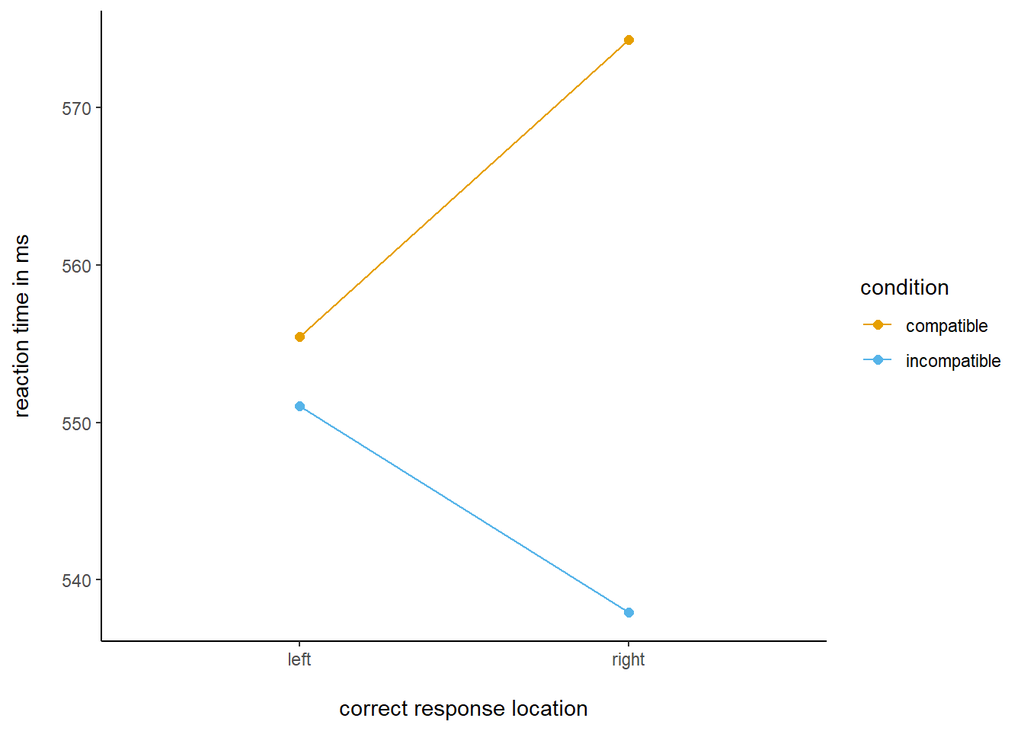

```r
ggplot(d_agg, aes(x = correct_response, y = mean_RT, color = condition)) +
  geom_point(size = 2) +
  geom_line(aes(group = condition)) +
  xlab("\ncorrect response location") +
  ylab("reaction time in ms\n") +
  theme_classic()
```

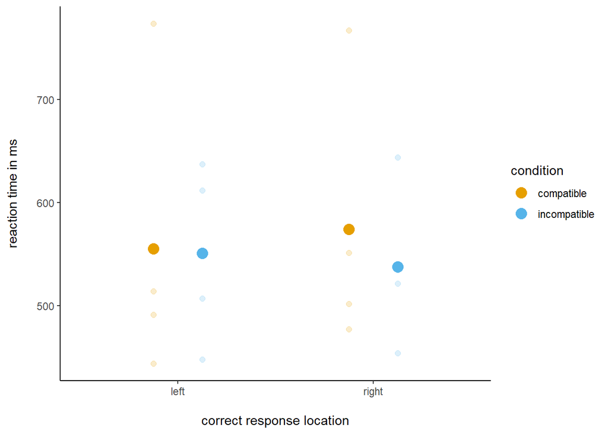

```r
ggplot(d_agg, aes(x = correct_response, y = mean_RT, color = condition)) +
  geom_point(aes(fill = condition), size = 4, position = position_dodge(width = 0.5)) +
  geom_point(data = d_agg_participant, aes(x = correct_response, y= mean_RT), size = 2, alpha = 0.2, position = position_dodge(width = 0.5)) +
  xlab("\ncorrect response location") +
  ylab("reaction time in ms\n") +
  theme_classic()
```

# Random effects model

We specify ‘compatible’ as default level for factor `condition`, and ‘right’ as default level for factor `correct_response`.

```r
d <- d %>%
    mutate(
      # Treat predictor variables as unordered factors
      condition = factor(condition, levels = c("compatible", "incompatible")),
      correct_response = factor(correct_response, levels = c("right", "left"))
  )

head(d)
```

```
##   submission_id  RT age  condition correctness handedness expected
## 1          1398 815  14 compatible     correct      right    small
## 2          1398 635  14 compatible     correct      right      big
## 3          1398 796  14 compatible     correct      right    small
## 4          1398 721  14 compatible     correct      right      big
## 5          1398 752  14 compatible     correct      right      big
## 6          1398 885  14 compatible     correct      right    small
##   experiment_id key_pressed  left            order right trial_number
## 1           155           q small compatible_first   big            2
## 2           155           p small compatible_first   big            3
## 3           155           q small compatible_first   big            4
## 4           155           p small compatible_first   big            5
## 5           155           p small compatible_first   big            6
## 6           155           q small compatible_first   big            7
##   trial_type outlier correct_response
## 1       main   FALSE             left
## 2       main   FALSE            right
## 3       main   FALSE             left
## 4       main   FALSE            right
## 5       main   FALSE            right
## 6       main   FALSE             left
```

## Model specification

```r
model_RE <- brm(
  formula = RT ~ condition*correct_response + (condition*correct_response||submission_id),
  data = d,
  iter = 4000,
  control = list(adapt_delta = 0.99, max_treedepth = 15),
  seed = 525
)
```

## Posterior estimates

```r
summary(model_RE)
```

```
##  Family: gaussian
##   Links: mu = identity; sigma = identity
## Formula: RT ~ condition * correct_response + (condition * correct_response || submission_id)
##    Data: d (Number of observations: 473)
## Samples: 4 chains, each with iter = 4000; warmup = 2000; thin = 1;
##          total post-warmup samples = 8000
##
## Group-Level Effects:
## ~submission_id (Number of levels: 4)
##                                                Estimate Est.Error l-95% CI
## sd(Intercept)                                    146.97     60.36    73.91
## sd(conditionincompatible)                         85.54     44.81    31.68
## sd(correct_responseleft)                          24.95     25.23     0.64
## sd(conditionincompatible:correct_responseleft)    71.36     42.93    16.45
##                                                u-95% CI Rhat Bulk_ESS Tail_ESS
## sd(Intercept)                                    297.18 1.00     4635     4734
## sd(conditionincompatible)                        200.31 1.00     4189     4261
## sd(correct_responseleft)                          90.68 1.00     3307     3693
## sd(conditionincompatible:correct_responseleft)   179.08 1.00     3647     3716
##
## Population-Level Effects:
##                                            Estimate Est.Error l-95% CI u-95% CI
## Intercept                                    565.56     62.67   435.76   687.72
## conditionincompatible                        -39.16     48.91  -141.86    56.22
## correct_responseleft                         -18.71     20.17   -58.98    21.15
## conditionincompatible:correct_responseleft    29.18     44.07   -64.64   114.60
##                                            Rhat Bulk_ESS Tail_ESS
## Intercept                                  1.00     3701     5257
## conditionincompatible                      1.00     3412     3614
## correct_responseleft                       1.00     5385     3514
## conditionincompatible:correct_responseleft 1.00     4360     4593
##
## Family Specific Parameters:
##       Estimate Est.Error l-95% CI u-95% CI Rhat Bulk_ESS Tail_ESS
## sigma    96.41      3.20    90.43   102.90 1.00    10049     4881
##
## Samples were drawn using sampling(NUTS). For each parameter, Bulk_ESS
## and Tail_ESS are effective sample size measures, and Rhat is the potential
## scale reduction factor on split chains (at convergence, Rhat = 1).
```

```r
prior_summary(model_RE)
```

```
##                       prior     class
## 1                                   b
## 2                                   b
## 3                                   b
## 4                                   b
## 5  student_t(3, 522, 118.6) Intercept
## 6    student_t(3, 0, 118.6)        sd
## 7                                  sd
## 8                                  sd
## 9                                  sd
## 10                                 sd
## 11                                 sd
## 12   student_t(3, 0, 118.6)     sigma
##                                          coef         group resp dpar nlpar
## 1
## 2                       conditionincompatible
## 3  conditionincompatible:correct_responseleft
## 4                        correct_responseleft
## 5
## 6
## 7                                             submission_id
## 8                       conditionincompatible submission_id
## 9  conditionincompatible:correct_responseleft submission_id
## 10                       correct_responseleft submission_id
## 11                                  Intercept submission_id
## 12
##    bound
## 1
## 2
## 3
## 4
## 5
## 6
## 7
## 8
## 9
## 10
## 11
## 12
```

```r
parameter_values <- posterior_samples(model_RE) %>%
  round(1) %>%
  select(b_Intercept,
         b_conditionincompatible,
         b_correct_responseleft,
         `b_conditionincompatible:correct_responseleft`) %>%
  pivot_longer(cols = everything(), names_to = "parameter", values_to = "value") %>%
  select(parameter, value)

head(parameter_values)
```

```
## # A tibble: 6 x 2
##   parameter                                    value
##   <chr>                                        <dbl>
## 1 b_Intercept                                  627.
## 2 b_conditionincompatible                        1.5
## 3 b_correct_responseleft                       -11.9
## 4 b_conditionincompatible:correct_responseleft  11.4
## 5 b_Intercept                                  487.
## 6 b_conditionincompatible                      -10.7
```

```r
parameter_summary <- model_RE %>%
  spread_draws(b_Intercept,
               b_conditionincompatible,
               b_correct_responseleft,
               `b_conditionincompatible:correct_responseleft`) %>%
  median_qi()


mean_values <- parameter_summary %>%
  pivot_longer(cols = c(b_Intercept, b_conditionincompatible, b_correct_responseleft,
                        `b_conditionincompatible:correct_responseleft`),
               names_to = "parameter",
               values_to = "mean") %>%
  select(parameter, mean)


lowerHDI <- parameter_summary %>%
  pivot_longer(cols = contains("lower"),
               names_to = "parameter_lower",
               values_to = "lower") %>%
  select(parameter_lower, lower)


upperHDI <- parameter_summary %>%
  pivot_longer(cols = contains("upper"),
               names_to = "parameter_upper",
               values_to = "upper") %>%
  select(parameter_upper, upper)


coefficients <- cbind(mean_values, lowerHDI, upperHDI) %>%
  select(-contains(c("_lower", "_upper")))


coefficients
```

```
##                                      parameter      mean      lower     upper
## 1                                  b_Intercept 566.95538  435.75859 687.71763
## 2                      b_conditionincompatible -37.72880 -141.85904  56.21689
## 3                       b_correct_responseleft -18.65965  -58.98240  21.15022
## 4 b_conditionincompatible:correct_responseleft  30.39448  -64.64136 114.60432
```

The following plot is inspired by a tutorial of Michael Franke and Timo Röttger (2019)[^1].

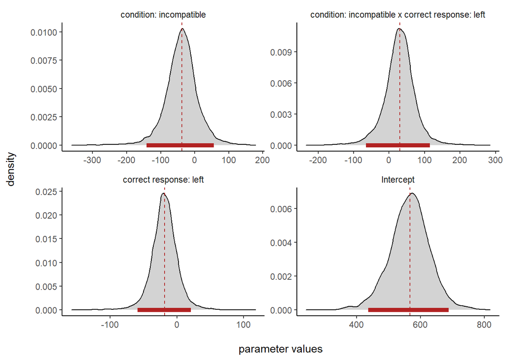

```r
new_labels <- c("b_Intercept" = "Intercept",
                "b_conditionincompatible" = "condition: incompatible",
                "b_correct_responseleft" = "correct response: left",
                "b_conditionincompatible:correct_responseleft" = "condition: incompatible x correct response: left")

ggplot(data = parameter_values, mapping = aes(x = value)) +
  geom_density(fill = "lightgrey") +
  geom_vline(data = coefficients, mapping = aes(xintercept = mean), color = "firebrick", lty = "dashed") +
  facet_wrap(.~parameter, scales = "free", labeller = labeller(parameter = new_labels))  +
  geom_segment(data = coefficients, mapping = aes(x=lower,xend= upper,y=0,yend=0), size = 2, color = "firebrick") +
  xlab("\nparameter values") +
  ylab("density\n") +
  theme_classic() +
  theme(strip.background = element_blank())
```

```r
# Extract the posterior estimates
derived_posteriors <- model_RE %>%
  spread_draws(b_Intercept,
               b_conditionincompatible,
               b_correct_responseleft,
               `b_conditionincompatible:correct_responseleft`) %>%
  # Calculate posteriors for each individual level
  mutate(Compatible_right = b_Intercept,
         Compatible_left = b_Intercept + b_correct_responseleft,
         Incompatible_right = b_Intercept + b_conditionincompatible,
         Incompatible_left = b_Intercept + b_conditionincompatible + b_correct_responseleft +
                              `b_conditionincompatible:correct_responseleft`) %>%
  select(Compatible_right, Compatible_left,
         Incompatible_right, Incompatible_left) %>%
  gather(key = "parameter", value = "posterior") %>%
   mutate(correct_response = ifelse(parameter == "Compatible_right" | parameter == "Incompatible_right",
                        "right", "left"),
          condition = ifelse(parameter == "Compatible_right" | parameter == "Compatible_left",
                        "compatible", "incompatible"))

# Summarize posterior means and 95% Credible Intervals for each combination of condition and correct_response
posteriors_agg <- derived_posteriors %>%
  group_by(correct_response, condition) %>%
  summarise(`|95%` = HDInterval::hdi(posterior, credMass = 0.95)[1],
            mean_posterior = mean(posterior),
            `95%|` = HDInterval::hdi(posterior, credMass = 0.95)[2])

posteriors_agg
```

```
## # A tibble: 4 x 5
## # Groups:   correct_response [2]
##   correct_response condition    `|95%` mean_posterior `95%|`
##   <chr>            <chr>         <dbl>          <dbl>  <dbl>
## 1 left             compatible     416.           547.   671.
## 2 left             incompatible   375.           537.   705.
## 3 right            compatible     438.           566.   689.
## 4 right            incompatible   381.           526.   671.
```

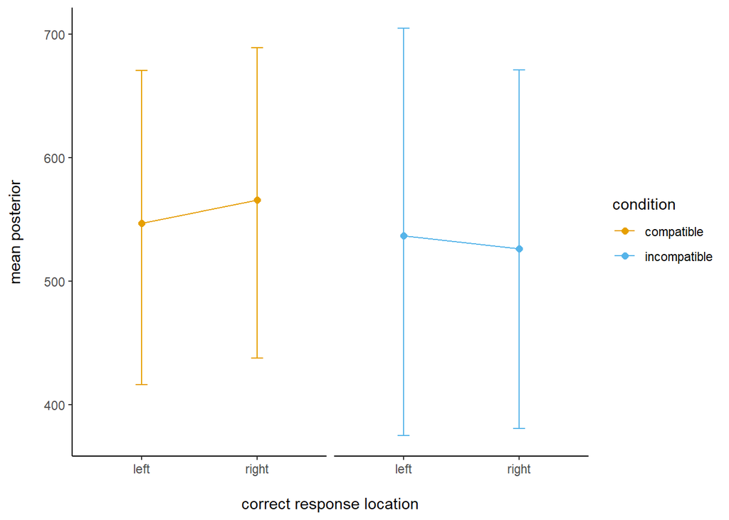

```r
# plot posterior estimates
posteriors_agg %>%
ggplot(aes(x = correct_response, y = mean_posterior, color = condition)) +
  geom_errorbar(aes(ymin = `|95%`, ymax = `95%|`),
                width = 0.1) +
  geom_line(aes(group = condition)) +
  geom_point(size = 2) +
  facet_wrap(.~condition) +
  theme_classic() +
  theme(strip.background = element_blank(), strip.text.x = element_blank()) +
  xlab("\ncorrect response location") +
  ylab("mean posterior\n")
```

# Hypothesis Testing

## Hypothesis 1

> Response times are faster in the compatible mapping condition than in the incompatible mapping condition.

```r
compare_groups(
  model = model_RE,
  higher = list("condition" = "compatible"),
  lower = list("condition" = "incompatible")
)
```

```
## Outcome of comparing groups:
##  * higher:  condition:compatible
##  * lower:   condition:incompatible
## Mean 'higher - lower':  24.57
## 95% CI: [ -74.6 ; 137.5 ]
## P('higher - lower' > 0):  0.7099
```

## Hypothesis 2

> The compatible S-R mapping yields lower reaction times for right responses than for left responses.

```r
compare_groups(
  model = model_RE,
  higher = list(condition = "compatible", correct_response = "right"),
  lower = list(condition = "compatible", correct_response = "left")
)
```

```
## Outcome of comparing groups:
##  * higher:  condition:compatible correct_response:right
##  * lower:   condition:compatible correct_response:left
## Mean 'higher - lower':  18.71
## 95% CI: [ -21.15 ; 58.98 ]
## P('higher - lower' > 0):  0.8628
```

## Hypothesis 3

> The incompatible S-R mapping yields higher reaction times for right responses than for left responses.

```r
compare_groups(
  model = model_RE,
  higher = list(condition = "incompatible", correct_response = "left"),
  lower = list(condition = "incompatible", correct_response = "right")
)
```

```
## Outcome of comparing groups:
##  * higher:  condition:incompatible correct_response:left
##  * lower:   condition:incompatible correct_response:right
## Mean 'higher - lower':  10.47
## 95% CI: [ -85.9 ; 102.2 ]
## P('higher - lower' > 0):  0.6362
```

[^1]: Franke, M., & Roettger, T. B. (2019, July 13). Bayesian regression modeling (for factorial designs): A tutorial. https://doi.org/10.31234/osf.io/cdxv3